# Reproducible Report on COVID19 Data

Faith L.

2025-04-20

## Covid19 Data Analysis

This report will be going over various statistics of both Global Data and US Data. Covid spread across the world and it is important to look into the different locations and see how each were impacted differently to look into what worked / didn’t work for future pandemics.

## About the Data

The data used for this report is from the Johns Hopkins Coronavirus Resource Center. The data is hosted by the Center for Systems Science and Engineering (CSSE) at Johns Hopkins University on Github. There is also a table containing information about the population data, also from Johns Hopkins that is used and can be seen in the uid object.

## Bias

There are many biases in the analysis and data. Covid deaths may not be counted or counted differently by area, or not even reported at all. Many covid cases may also not be counted, especially in more rural areas. Along with that different countries/ states may have different capabilities to even get the data, so different countries will most likely have a different percentage of counted cases/deaths versus uncounted cases/deaths. Deaths are also more likely to be counted for this data set when comparing to covid cases.

## Reproduction Information

The only library used in this project is tidyverse and is imported below. Also listed is the session information in the event of version interference.

```r
library(tidyverse)
```

[session information not shown]

### Importing Source Data

```r
url <- "https://raw.githubusercontent.com/CSSEGISandData/COVID-19/master/csse_covid_19_data/csse_covid_19_time_series/"

file_names <- c("time_series_covid19_confirmed_US.csv",  "time_series_covid19_confirmed_global.csv", "time_series_covid19_deaths_US.csv",  "time_series_covid19_deaths_global.csv")

uid_lookup_url <- "https://raw.githubusercontent.com/CSSEGISandData/COVID-19/4360e50239b4eb6b22f3a1759323748f36752177/csse_covid_19_data/UID_ISO_FIPS_LookUp_Table.csv"

uid <- read_csv(uid_lookup_url)
urls <- str_c(url, file_names)

US_cases <- read_csv(urls[1], show_col_types = FALSE )
global_cases <- read_csv(urls[2], show_col_types = FALSE)
US_deaths <- read_csv(urls[3], show_col_types = FALSE)
global_deaths <- read_csv(urls[4], show_col_types = FALSE)
```

### Data Reformatting

The below chunks goes over the code used to reformat the data for better use in our analysis. For the US data, the date column was also reformatted to datetime.

```r
# long pivot for all tables

#global data
global_cases <- global_cases %>% pivot_longer(cols = -c('Province/State', 'Country/Region', Lat, Long), names_to="date", values_to="cases") %>%
  select(-c(Lat,Long))
global_deaths <- global_deaths %>% pivot_longer(cols = -c('Province/State', 'Country/Region', Lat, Long), names_to="date", values_to="deaths") %>%
  select(-c(Lat,Long))

#us data
US_deaths <- US_deaths %>%
  pivot_longer(cols = -(UID:Population),
               names_to = "date",
               values_to = "deaths") %>%
  select(Admin2:deaths) %>%
  mutate(date = mdy(date)) %>%
  select(-c(Lat, Long_))

US_cases <- US_cases %>%
  pivot_longer(cols = -(UID:Combined_Key),
               names_to = "date",
               values_to = "cases") %>%
  select(Admin2:cases) %>%
  mutate(date = mdy(date)) %>%
  select(-c(Lat, Long_))
```

### Data Merge

The data sets were merged into one consisting of both cases and deaths.

```r
# Combining global cases and deaths
global <- global_cases %>%
  full_join(global_deaths) %>%
  rename(Country_Region = 'Country/Region',
         Province_State = 'Province/State') %>%
  mutate(date = mdy(date))
# creating a new combined key column of province_state, country_region.
global <- global %>%
  unite("Combined_Key", c(Province_State, Country_Region),
        sep = ", ",
        na.rm = TRUE,
        remove = FALSE)

# adding the global population data from the uid object.
global <- global %>%
  left_join(uid, by= c("Province_State", "Country_Region", "Combined_Key"))

# keeping specific columns for global
global <- global %>%
  select(Province_State, Country_Region, date,
         cases, deaths, Population, Combined_Key)

# Combining US Cases and Deaths
US <- US_cases %>%
  full_join(US_deaths)
```

[output not shown]

[output not shown]

```r
US_totals <- US_by_state %>%
  group_by(Country_Region, date) %>%
  summarize(cases = sum(cases), deaths = sum(deaths), Population = sum(Population)) %>%
  mutate(deaths_per_mil = deaths * 1000000 / Population) %>%
  select(Country_Region, date, cases, deaths, deaths_per_mil, Population) %>%
  ungroup() %>%
  filter(cases > 0)
```

## US Cases Graphs

Below are the graphs of the US_totals, along with a graph for Texas specifically.

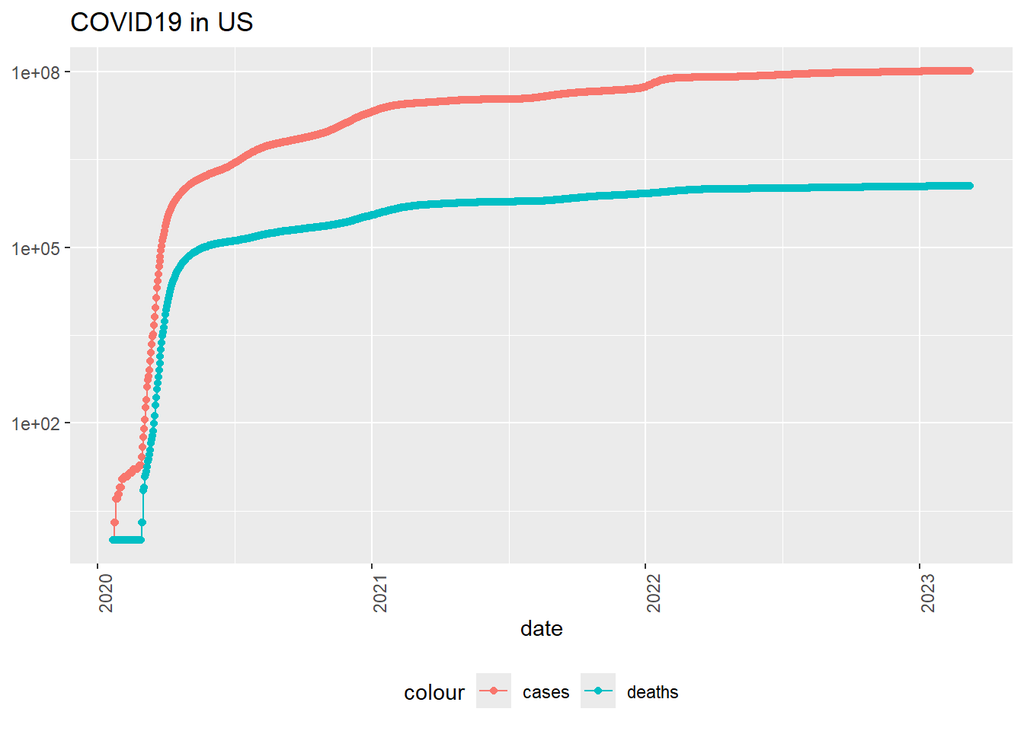

```r
US_totals %>%
  ggplot(aes(x=date, y=cases)) +
    geom_line(aes(color="cases")) +
    geom_point(aes(color = "cases")) +
    geom_line(aes(y=deaths, color="deaths")) +
    geom_point(aes(y=deaths, color="deaths")) +
    scale_y_log10() +
    theme(legend.position = "bottom", axis.text.x = element_text(angle=90)) +
    labs(title="COVID19 in US", y=NULL)
```

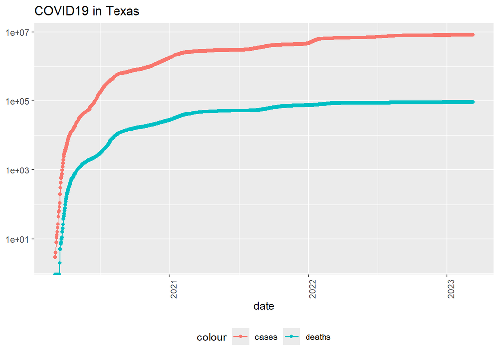

```r
state <- "Texas"
US_by_state %>%
  filter(Province_State == state) %>%
  filter(cases > 0) %>%
  ggplot(aes(x=date, y=cases)) +
  geom_line(aes(color="cases")) +
  geom_point(aes(color = "cases")) +
  geom_line(aes(y=deaths, color="deaths")) +
  geom_point(aes(y=deaths, color="deaths")) +
  scale_y_log10() +
  theme(legend.position = "bottom", axis.text.x = element_text(angle=90)) +
  labs(title=str_c("COVID19 in ", state), y=NULL)
```

## US Summary Statistics

```r
US_state_totals <- US_by_state %>%
  group_by(Province_State) %>%
  summarize(deaths=max(deaths), cases=max(cases),
            population = max(Population),
            cases_per_thou = 1000* cases/ Population,
            deaths_per_thou = 1000* deaths / Population) %>%
  filter(cases >0, population>0) %>%
  ungroup()
US_state_totals <- US_state_totals[!duplicated(US_state_totals), ] # removing duplicates

US_state_totals %>%
  slice_min(deaths_per_thou, n=10) %>%
  select(deaths_per_thou, cases_per_thou, everything())
```

```
## # A tibble: 10 × 6
##    deaths_per_thou cases_per_thou Province_State        deaths  cases population
##              <dbl>          <dbl> <chr>                  <dbl>  <dbl>      <dbl>
##  1           0.611           150. American Samoa            34 8.32e3      55641
##  2           0.744           248. Northern Mariana Isl…     41 1.37e4      55144
##  3           1.21            231. Virgin Islands           130 2.48e4     107268
##  4           1.30            269. Hawaii                  1841 3.81e5    1415872
##  5           1.49            245. Vermont                  929 1.53e5     623989
##  6           1.55            293. Puerto Rico             5823 1.10e6    3754939
##  7           1.65            340. Utah                    5298 1.09e6    3205958
##  8           2.01            415. Alaska                  1486 3.08e5     740995
##  9           2.03            252. District of Columbia    1432 1.78e5     705749
## 10           2.06            253. Washington             15683 1.93e6    7614893
```

### Conclusion

Covid data impacted every state.